# P4_project

Nok Chan

Tuesday, August 02, 2016

========================================================

```
##  [1] "ListingKey"
##  [2] "ListingNumber"
##  [3] "ListingCreationDate"
##  [4] "CreditGrade"
##  [5] "Term"
##  [6] "LoanStatus"
##  [7] "ClosedDate"
##  [8] "BorrowerAPR"
##  [9] "BorrowerRate"
## [10] "LenderYield"
## [11] "EstimatedEffectiveYield"
## [12] "EstimatedLoss"
## [13] "EstimatedReturn"
## [14] "ProsperRating..numeric."
## [15] "ProsperRating..Alpha."
```

[output cut: 66 more lines]

# Questions

- What people is likely to return debts?
- What people is unlikely to return debts?
- What people should take action to urge them to pay debts?
- What are the factors that affect the loan amount?

# Univariate Plots Section

```
## [1] "Number of Observations:"
```

```
## [1] 113937
```

```
## [1] "Number of Features:"
```

```
## [1] 81
```

```
## [1] "Selected features :"
```

```
##   LoanStatus CreditGrade ProsperScore ProsperRating..Alpha. ProsperScore.1
## 1  Completed           C           NA                                   NA
## 2    Current                        7                     A              7
## 3  Completed          HR           NA                                   NA
## 4    Current                        9                     A              9
## 5    Current                        4                     D              4
## 6    Current                       10                     B             10
##   ListingCategory..numeric. DebtToIncomeRatio StatedMonthlyIncome
## 1                         0              0.17            3083.333
## 2                         2              0.18            6125.000
## 3                         0              0.06            2083.333
## 4                        16              0.15            2875.000
## 5                         2              0.26            9583.333
## 6                         1              0.36            8333.333
##   IsBorrowerHomeowner LoanOriginalAmount MonthlyLoanPayment    IncomeRange
## 1                True               9425             330.43 $25,000-49,999
## 2               False              10000             318.93 $50,000-74,999
## 3               False               3001             123.32  Not displayed
## 4                True              10000             321.45 $25,000-49,999
## 5                True              15000             563.97      $100,000+
## 6                True              15000             342.37      $100,000+
##   LP_NetPrincipalLoss
## 1                   0
## 2                   0
## 3                   0
## 4                   0
## 5                   0
## 6                   0
```

```
##                  LoanStatus     CreditGrade     ProsperScore
##  Current              :56576          :84984   Min.   : 1.00
##  Completed            :38074   C      : 5649   1st Qu.: 4.00
##  Chargedoff           :11992   D      : 5153   Median : 6.00
##  Defaulted            : 5018   B      : 4389   Mean   : 5.95
##  Past Due (1-15 days) :  806   AA     : 3509   3rd Qu.: 8.00
##  Past Due (31-60 days):  363   HR     : 3508   Max.   :11.00
##  (Other)              : 1108   (Other): 6745   NA's   :29084
##  ProsperRating..Alpha. ProsperScore.1  ListingCategory..numeric.
##         :29084         Min.   : 1.00   Min.   : 0.000
##  C      :18345         1st Qu.: 4.00   1st Qu.: 1.000
##  B      :15581         Median : 6.00   Median : 1.000
##  A      :14551         Mean   : 5.95   Mean   : 2.774
##  D      :14274         3rd Qu.: 8.00   3rd Qu.: 3.000
##  E      : 9795         Max.   :11.00   Max.   :20.000
##  (Other):12307         NA's   :29084
##  DebtToIncomeRatio StatedMonthlyIncome IsBorrowerHomeowner
##  Min.   : 0.000    Min.   :      0     False:56459
##  1st Qu.: 0.140    1st Qu.:   3200     True :57478
##  Median : 0.220    Median :   4667
##  Mean   : 0.276    Mean   :   5608
##  3rd Qu.: 0.320    3rd Qu.:   6825
##  Max.   :10.010    Max.   :1750003
##  NA's   :8554
##  LoanOriginalAmount MonthlyLoanPayment         IncomeRange
##  Min.   : 1000      Min.   :   0.0     $25,000-49,999:32192
##  1st Qu.: 4000      1st Qu.: 131.6     $50,000-74,999:31050
##  Median : 6500      Median : 217.7     $100,000+     :17337
##  Mean   : 8337      Mean   : 272.5     $75,000-99,999:16916
##  3rd Qu.:12000      3rd Qu.: 371.6     Not displayed : 7741
##  Max.   :35000      Max.   :2251.5     $1-24,999     : 7274
##                                        (Other)       : 1427
##  LP_NetPrincipalLoss
##  Min.   : -954.5
##  1st Qu.:    0.0
##  Median :    0.0
##  Mean   :  681.4
##  3rd Qu.:    0.0
##  Max.   :25000.0
##
```

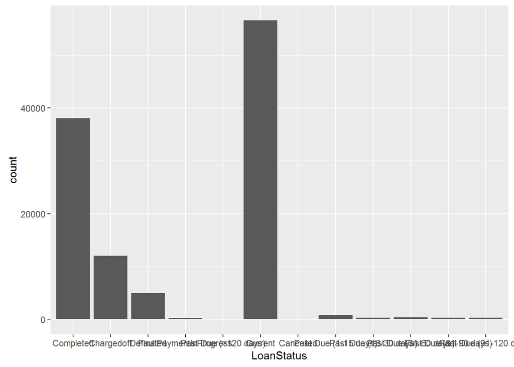

```
##                  LoanStatus
##  Current              :56576
##  Completed            :38074
##  Chargedoff           :11992
##  Defaulted            : 5018
##  Past Due (1-15 days) :  806
##  Past Due (31-60 days):  363
##  (Other)              : 1108
```

[output not shown]

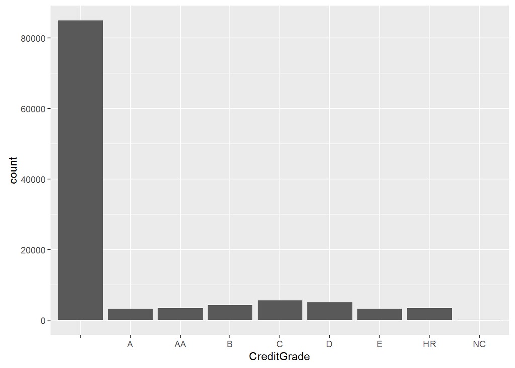

```
##   CreditGrade
##         :84984
##  C      : 5649
##  D      : 5153
##  B      : 4389
##  AA     : 3509
##  HR     : 3508
##  (Other): 6745
```

[output not shown]

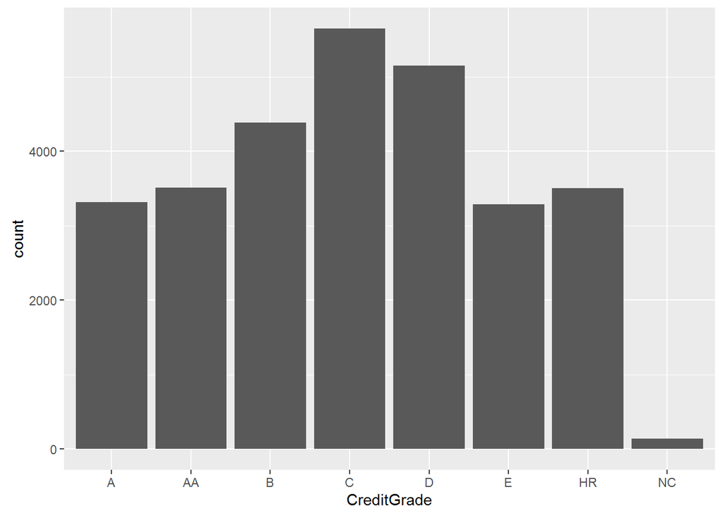

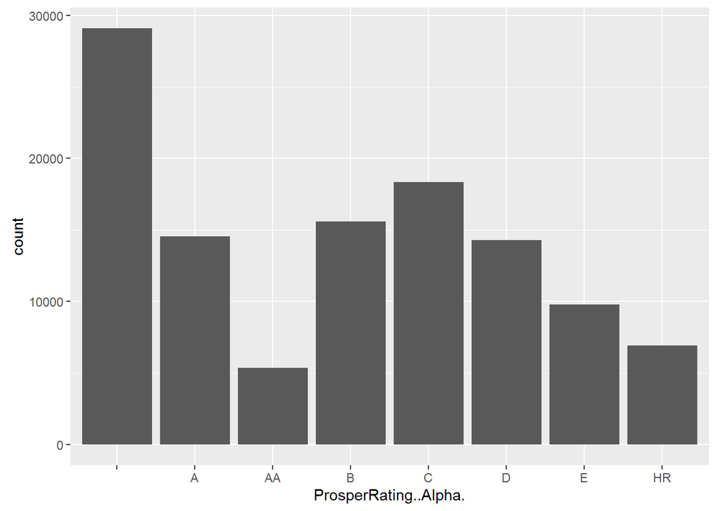

```
##  ProsperRating..Alpha.
##         :29084
##  C      :18345
##  B      :15581
##  A      :14551
##  D      :14274
##  E      : 9795
##  (Other):12307
```

[output not shown]

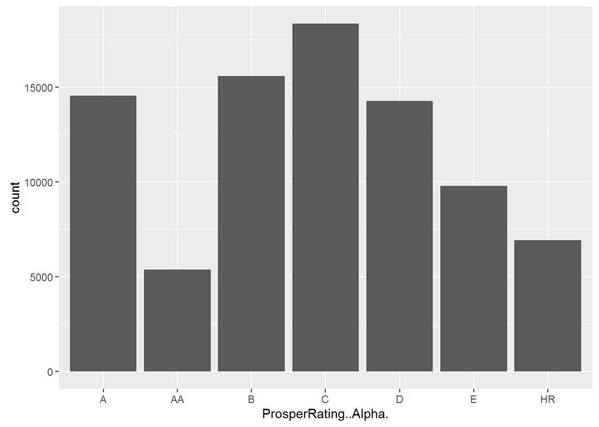

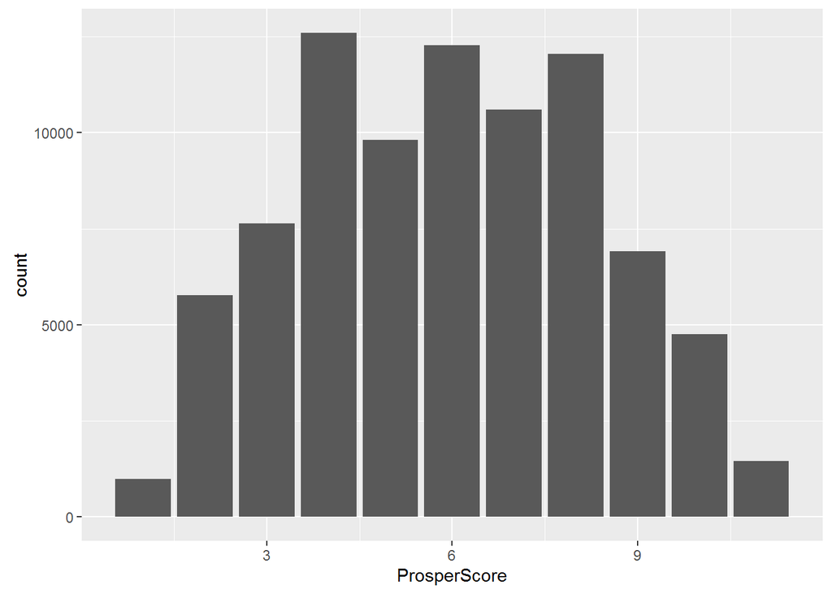

```
##   ProsperScore
##  Min.   : 1.00
##  1st Qu.: 4.00
##  Median : 6.00
##  Mean   : 5.95
##  3rd Qu.: 8.00
##  Max.   :11.00
##  NA's   :29084
```

[output not shown]

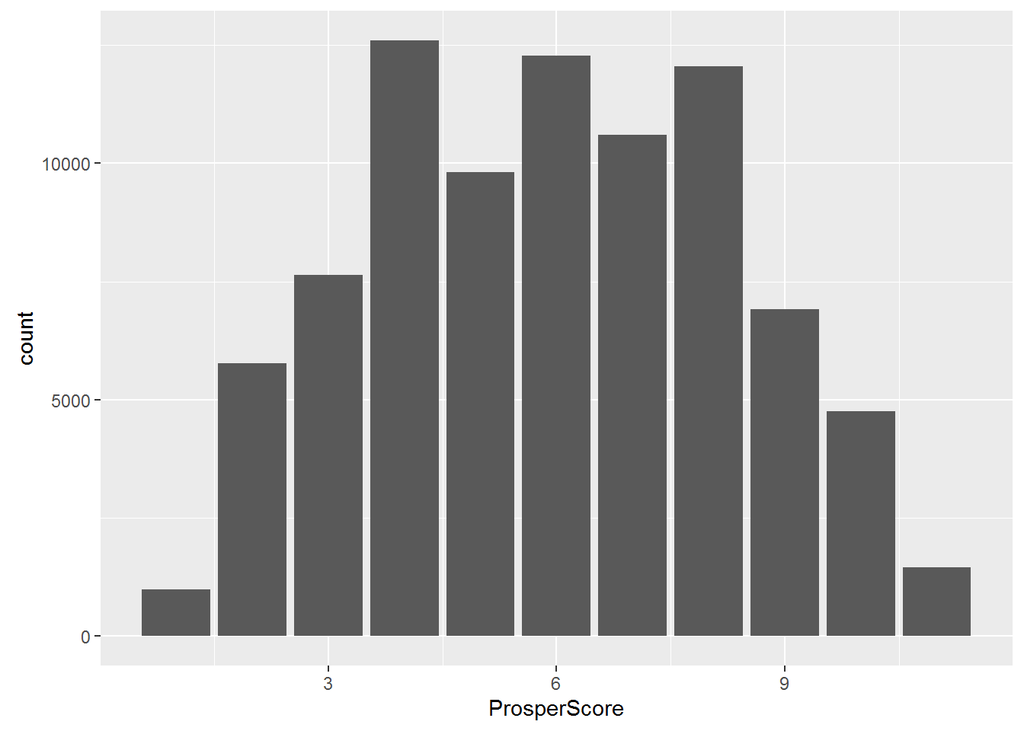

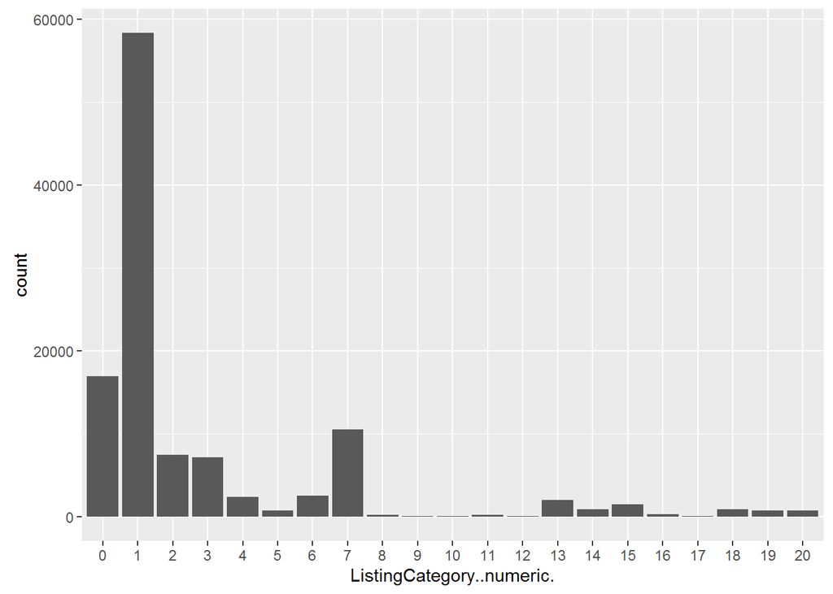

```
##  ListingCategory..numeric.
##  1      :58308
##  0      :16965
##  7      :10494
##  2      : 7433
##  3      : 7189
##  6      : 2572
##  (Other):10976
```

[output not shown]

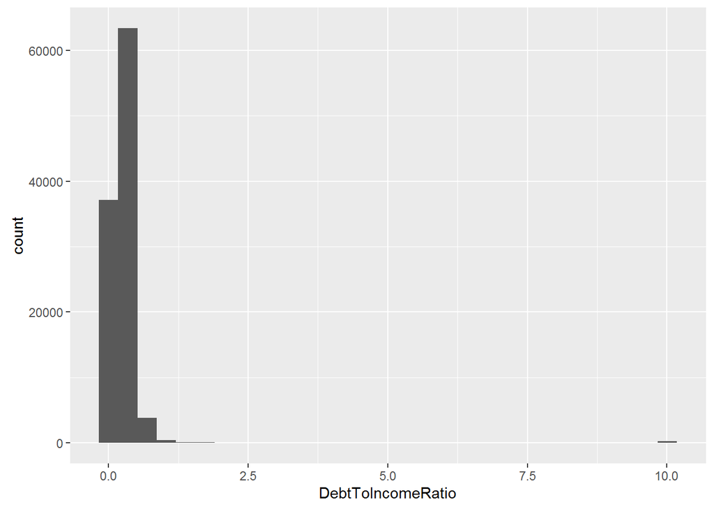

```
##  DebtToIncomeRatio
##  Min.   : 0.000
##  1st Qu.: 0.140
##  Median : 0.220
##  Mean   : 0.276
##  3rd Qu.: 0.320
##  Max.   :10.010
##  NA's   :8554
```

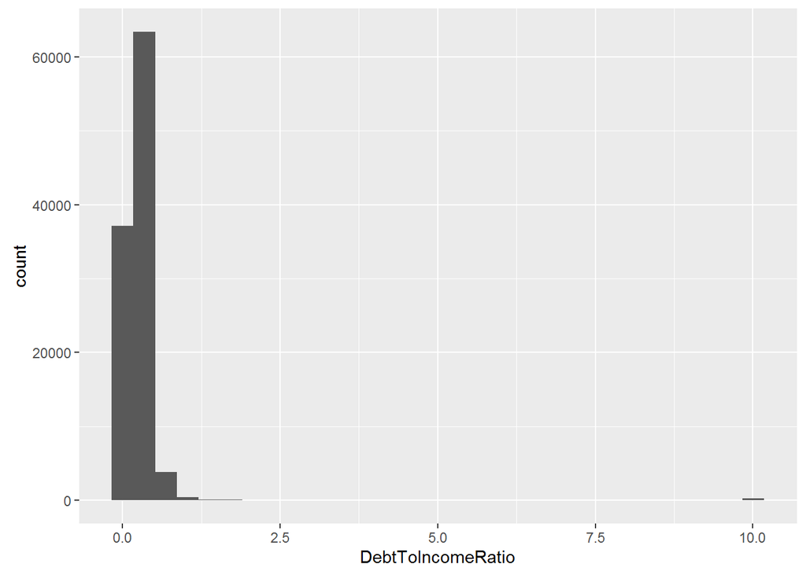

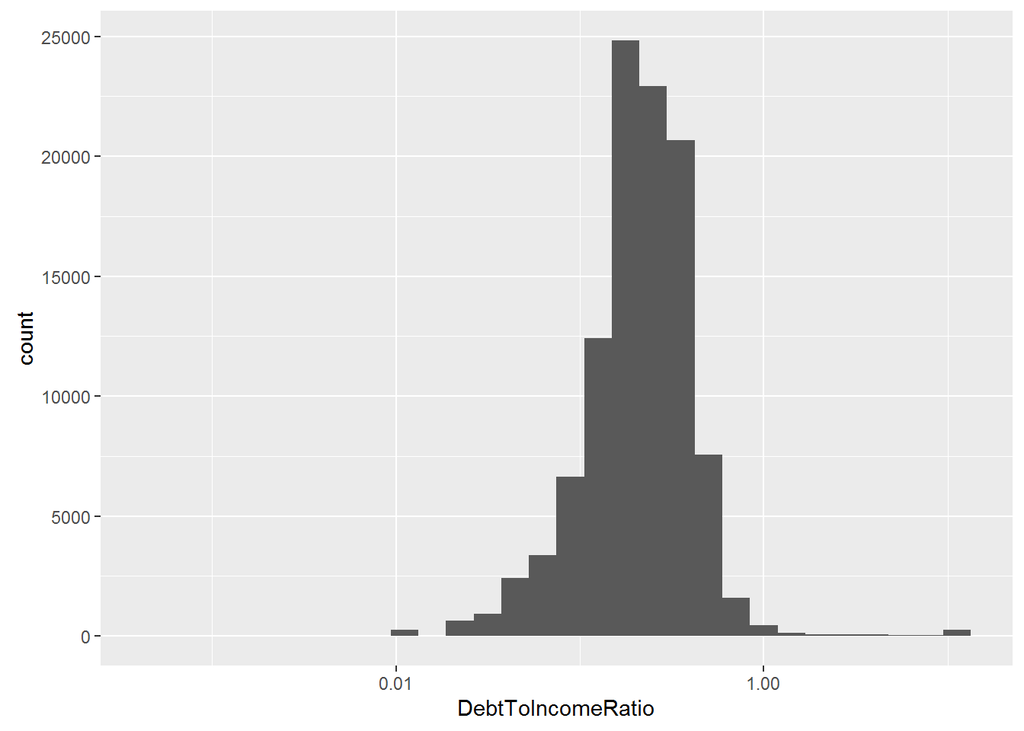

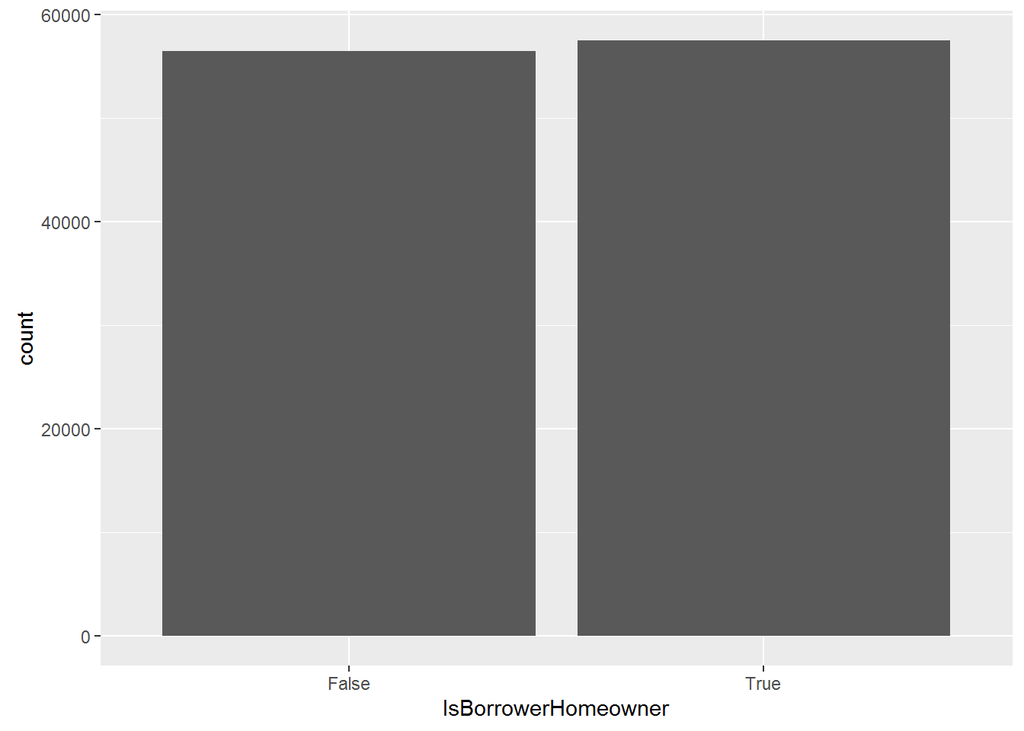

```
##  IsBorrowerHomeowner
##  False:56459
##  True :57478
```

[output not shown]

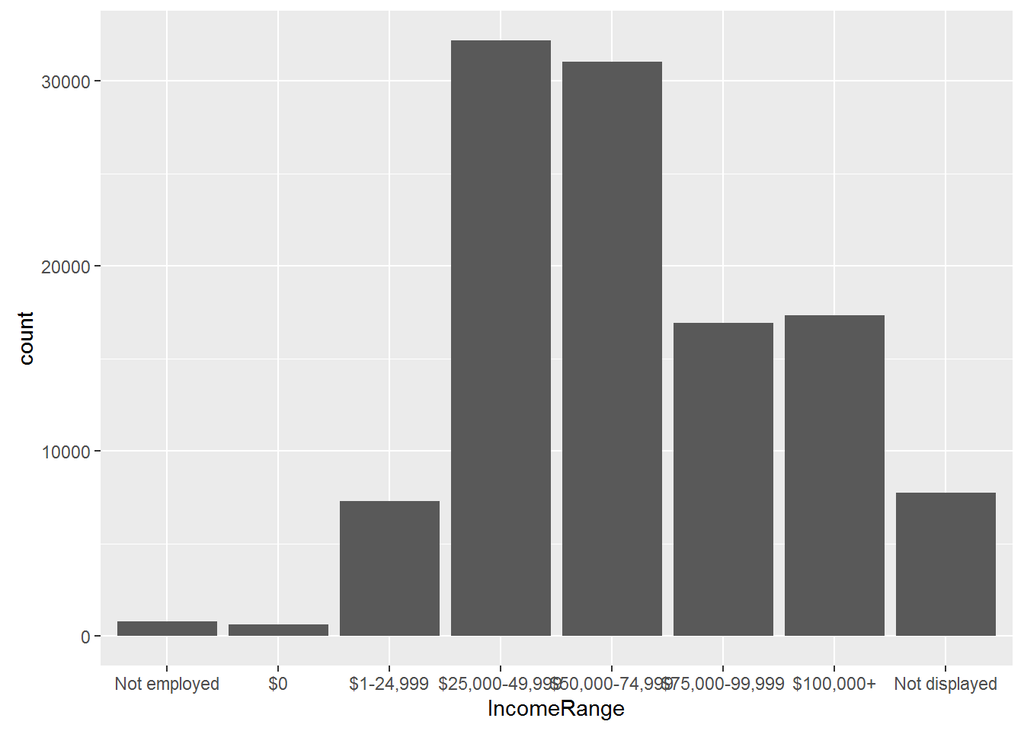

```
##          IncomeRange
##  $25,000-49,999:32192
##  $50,000-74,999:31050
##  $100,000+     :17337
##  $75,000-99,999:16916
##  Not displayed : 7741
##  $1-24,999     : 7274
##  (Other)       : 1427
```

[output not shown]

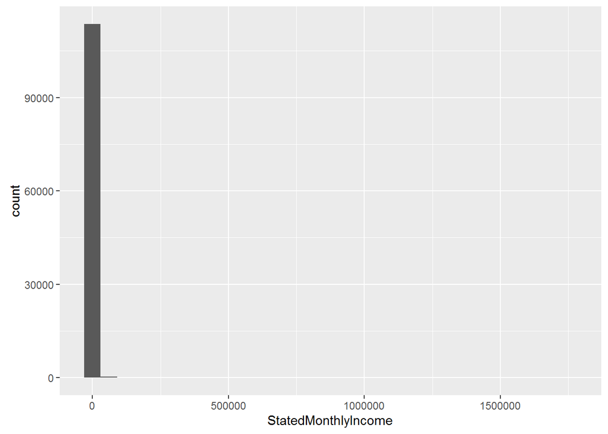

```
##  StatedMonthlyIncome
##  Min.   :      0
##  1st Qu.:   3200
##  Median :   4667
##  Mean   :   5608
##  3rd Qu.:   6825
##  Max.   :1750003
```

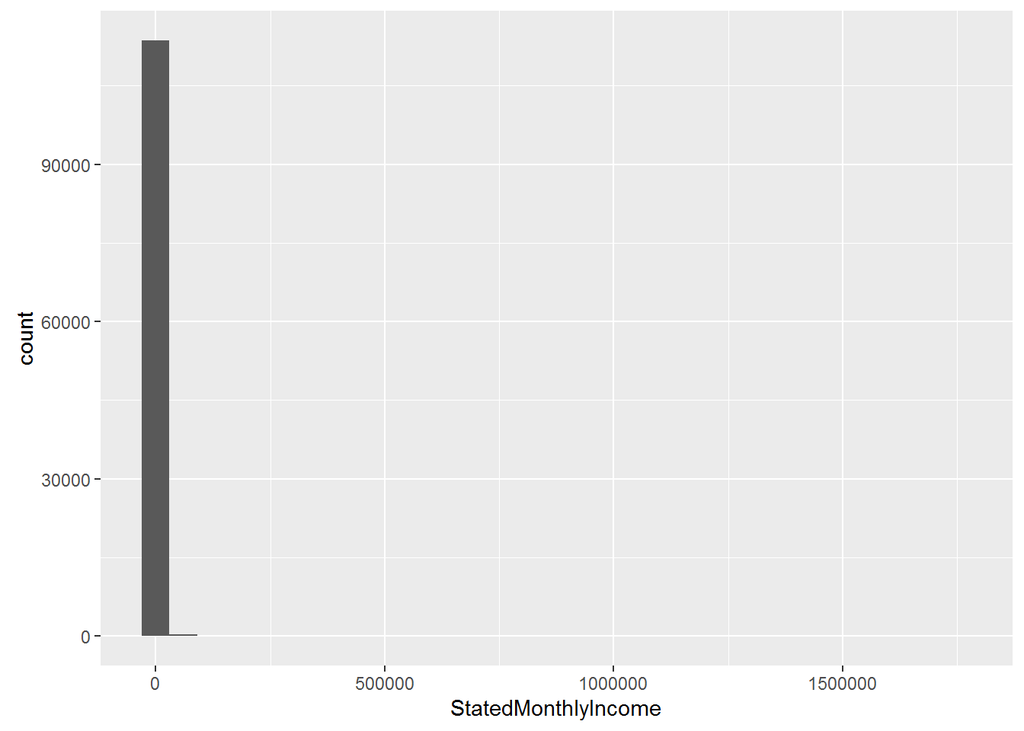

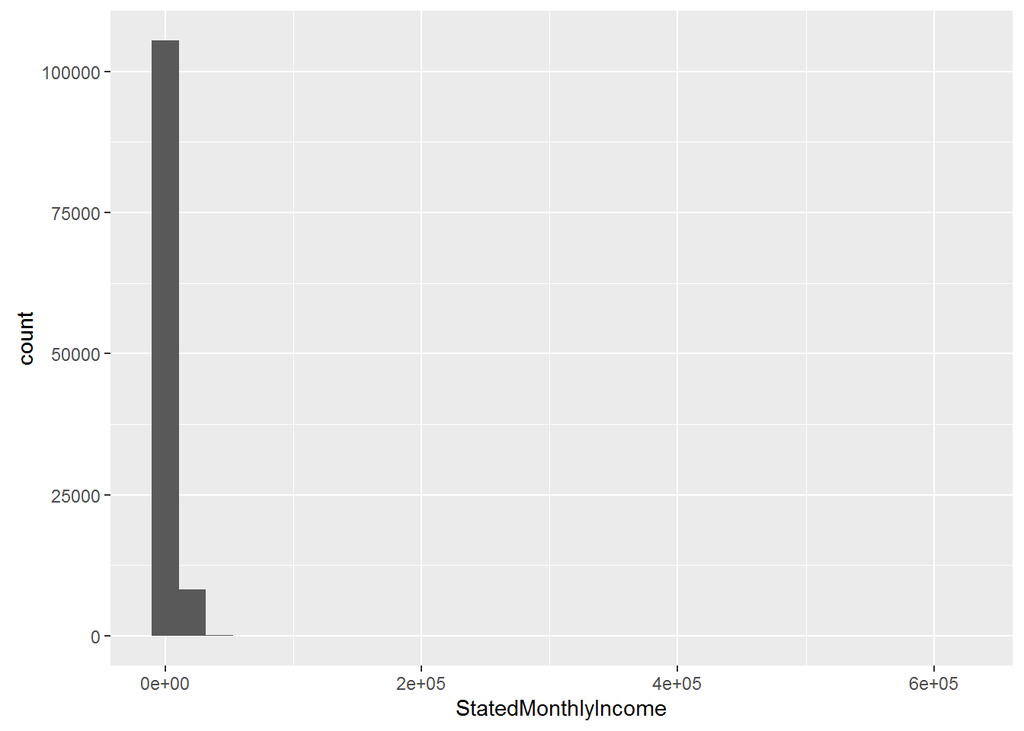

```
##  StatedMonthlyIncome
##  Min.   :     0
##  1st Qu.:  3200
##  Median :  4667
##  Mean   :  5593
##  3rd Qu.:  6825
##  Max.   :618548
##  NA's   :1
```

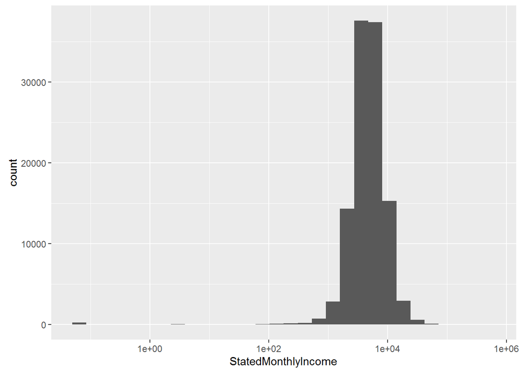

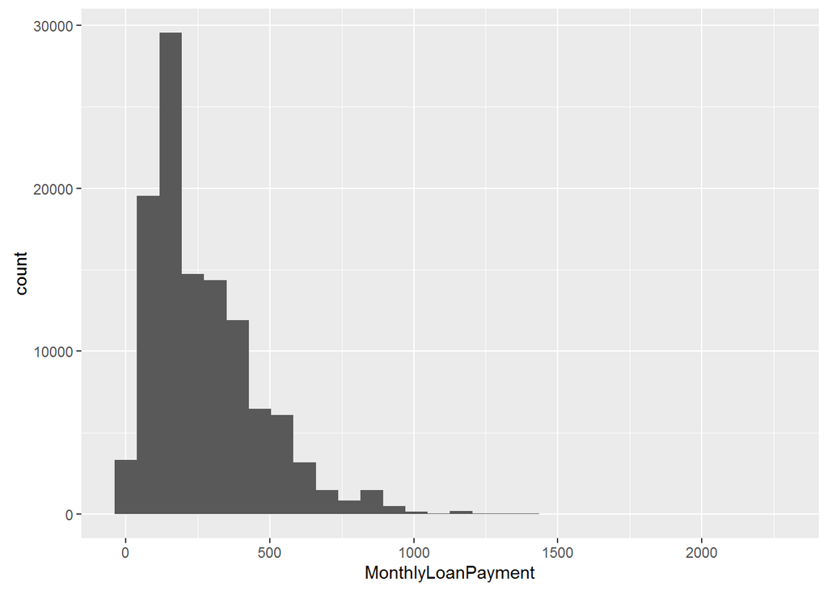

```
##  MonthlyLoanPayment
##  Min.   :   0.0
##  1st Qu.: 131.6
##  Median : 217.7
##  Mean   : 272.5
##  3rd Qu.: 371.6
##  Max.   :2251.5
```

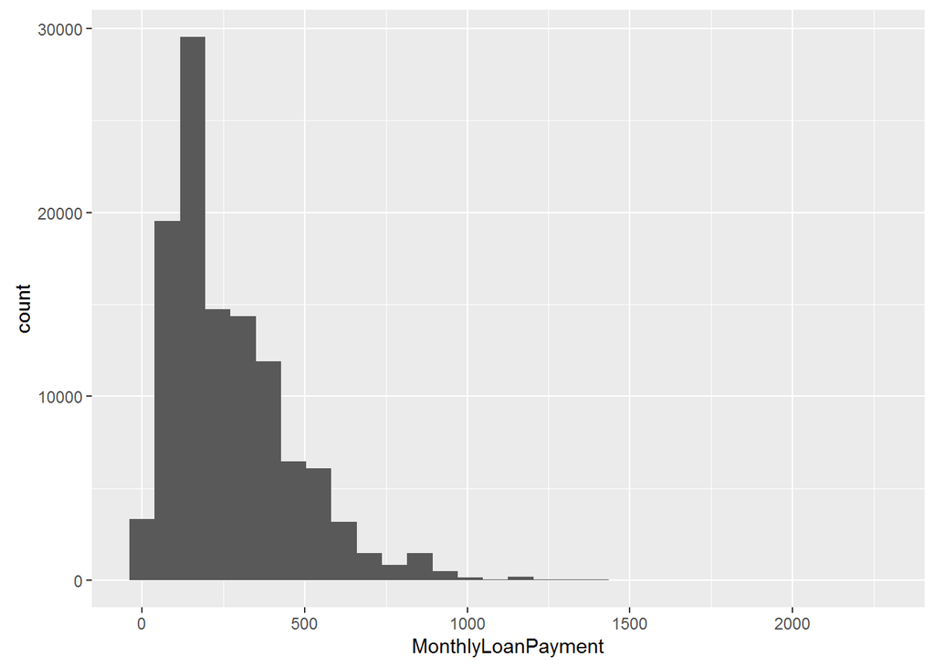

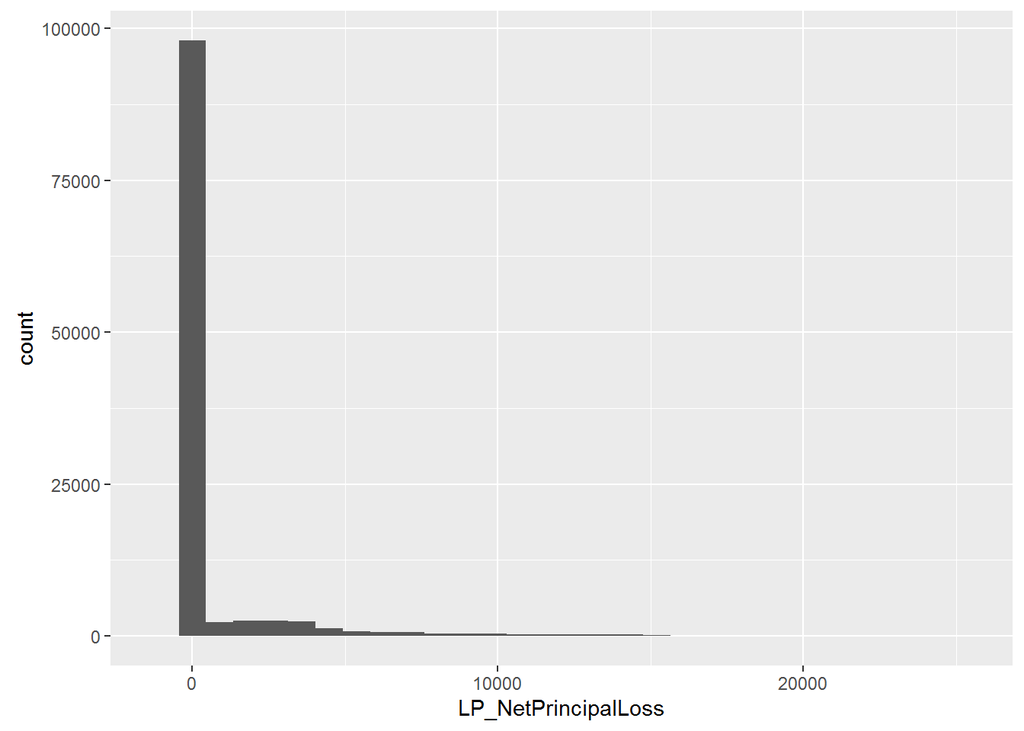

```
##  LP_NetPrincipalLoss
##  Min.   : -954.5
##  1st Qu.:    0.0
##  Median :    0.0
##  Mean   :  681.4
##  3rd Qu.:    0.0
##  Max.   :25000.0
```

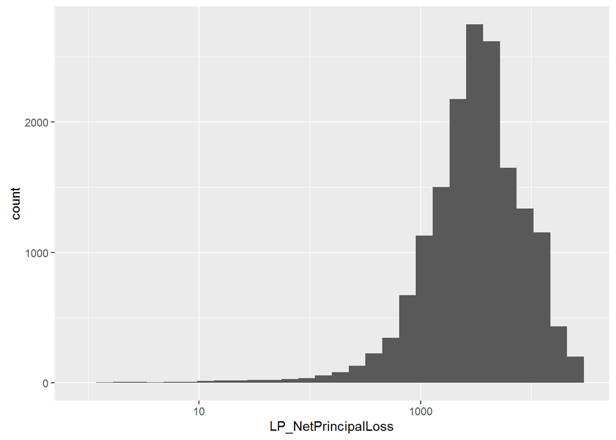

```
## [1] "Total Principal Loss:"
```

```
## [1] 77639007
```

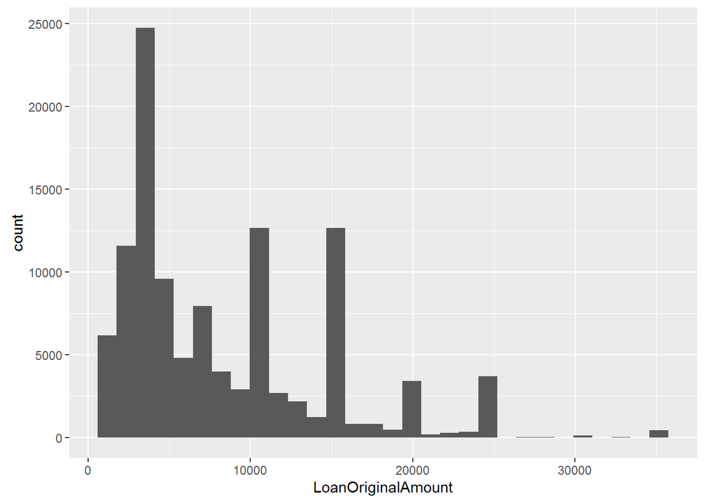

```
##  LoanOriginalAmount
##  Min.   : 1000
##  1st Qu.: 4000
##  Median : 6500
##  Mean   : 8337
##  3rd Qu.:12000
##  Max.   :35000
```

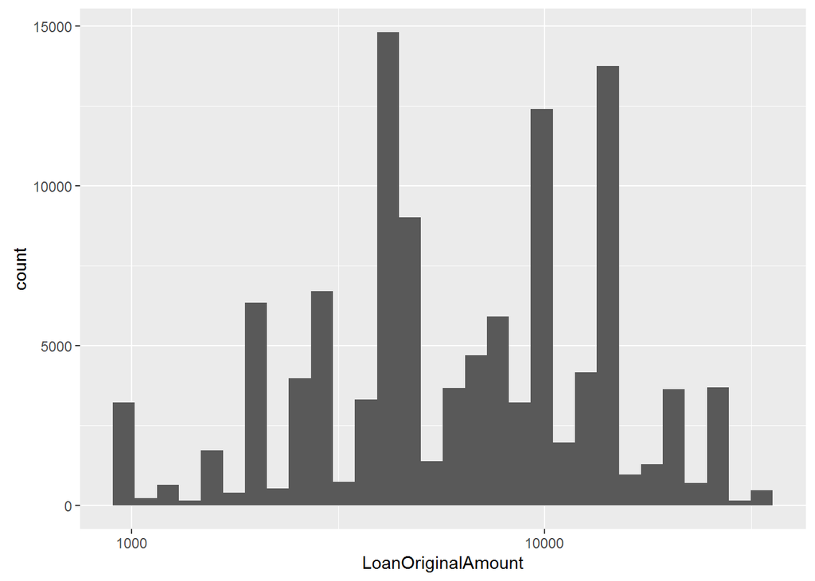

```
##
##  1000  1500  2000  2500  3000  3500  4000  4500  5000  6000  6500  7000
##  3206  1507  6067  2992  5749  2567 14333  1406  6990  2869  1343  2949
##  7500  8000  8500  9000 10000 12000 13000 15000 20000 25000
##  2975  2442  1059  1695 11106  1921  1509 12407  3291  3630
```

[figure not shown]

# Univariate Analysis

### What is the structure of your dataset?

The data contain 113937 observations, 81 variables, which is a intermediate size dataset.

### What is/are the main feature(s) of interest in your dataset?

Loan Amount,Loan Status

### What other features in the dataset do you think will help support your investigation into your feature(s) of interest?

“ProsperScore” ,“ListingCategory..numeric.”, “DebtToIncomeRatio” ,“StatedMonthlyIncome” , “IsBorrowerHomeowner” ,“LoanOriginalAmount” ,“MonthlyLoanPayment”, “IncomeRange”

# Bivariate Plots Section

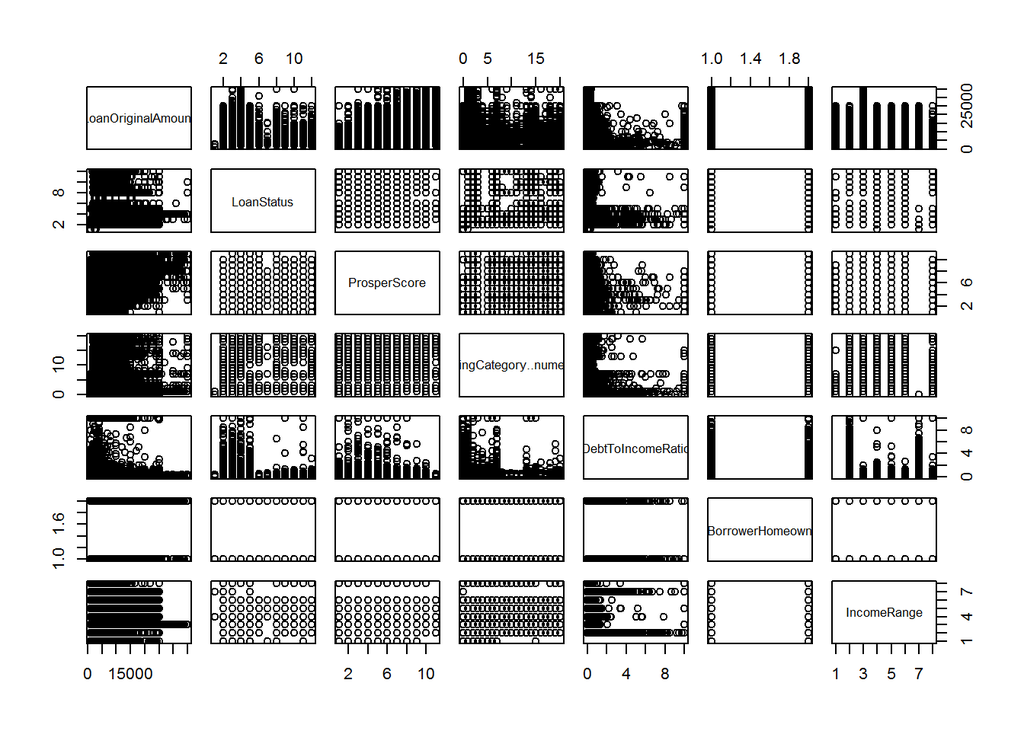

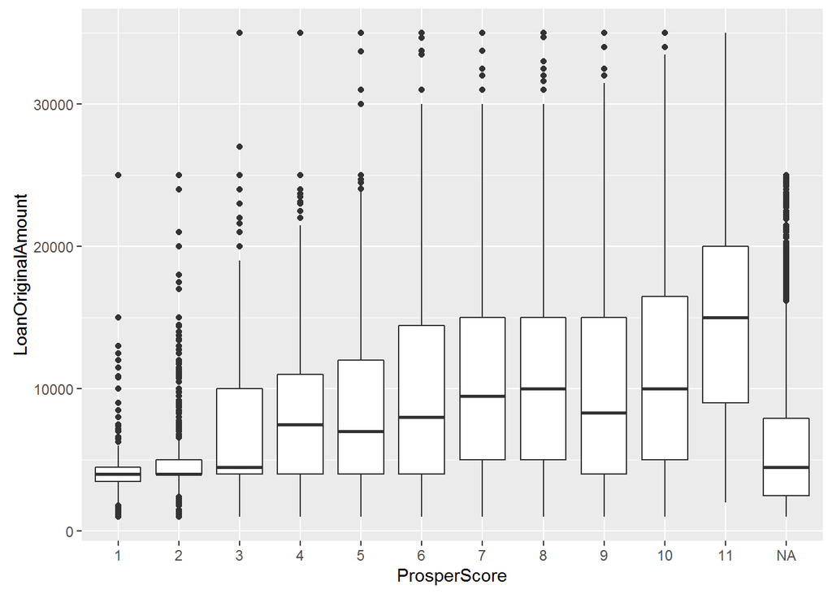

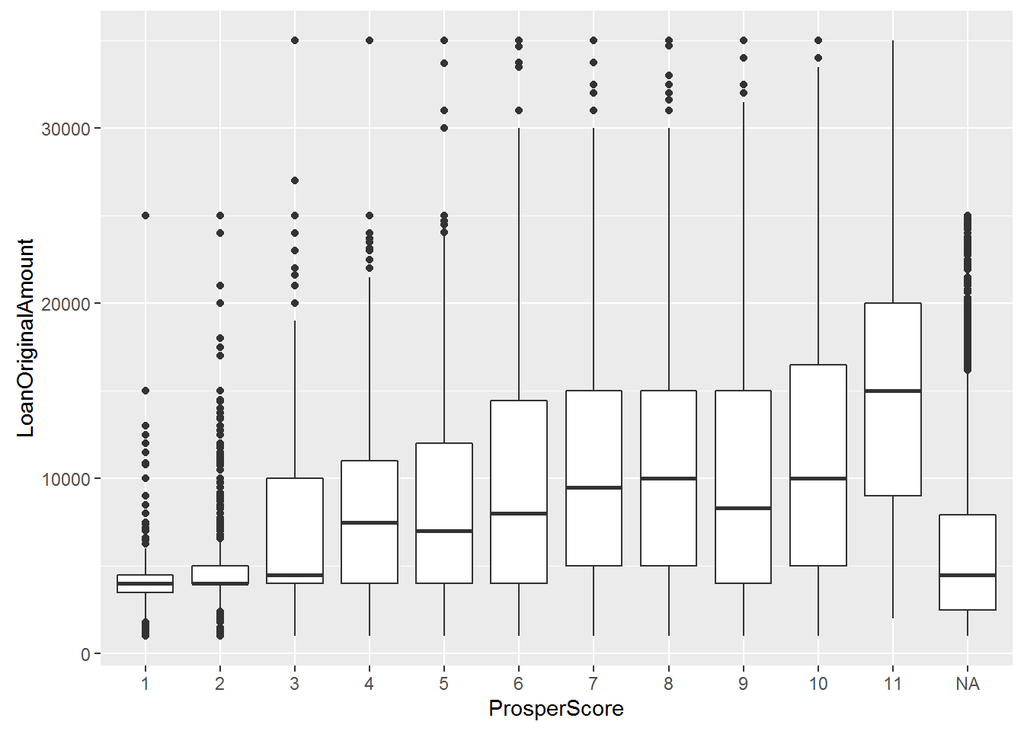

```
## $`1`
##    Min. 1st Qu.  Median    Mean 3rd Qu.    Max.
##    1000    3500    4000    4571    4500   25000
##
## $`2`
##    Min. 1st Qu.  Median    Mean 3rd Qu.    Max.
##    1000    4000    4000    5280    5000   25000
##
## $`3`
##    Min. 1st Qu.  Median    Mean 3rd Qu.    Max.
##    1000    4000    4500    7063   10000   35000
##
## $`4`
##    Min. 1st Qu.  Median    Mean 3rd Qu.    Max.
##    1000    4000    7500    8402   11000   35000
##
## $`5`
##    Min. 1st Qu.  Median    Mean 3rd Qu.    Max.
##    1000    4000    7000    8400   12000   35000
##
## $`6`
##    Min. 1st Qu.  Median    Mean 3rd Qu.    Max.
##    1000    4000    8000    9223   14420   35000
##
## $`7`
##    Min. 1st Qu.  Median    Mean 3rd Qu.    Max.
##    1000    5000    9500   10100   15000   35000
##
## $`8`
##    Min. 1st Qu.  Median    Mean 3rd Qu.    Max.
##    1000    5000   10000   10490   15000   35000
##
## $`9`
##    Min. 1st Qu.  Median    Mean 3rd Qu.    Max.
##    1000    4000    8300   10060   15000   35000
##
## $`10`
##    Min. 1st Qu.  Median    Mean 3rd Qu.    Max.
##    1000    5000   10000   11740   16500   35000
##
## $`11`
##    Min. 1st Qu.  Median    Mean 3rd Qu.    Max.
##    2000    9000   15000   14860   20000   35000
```

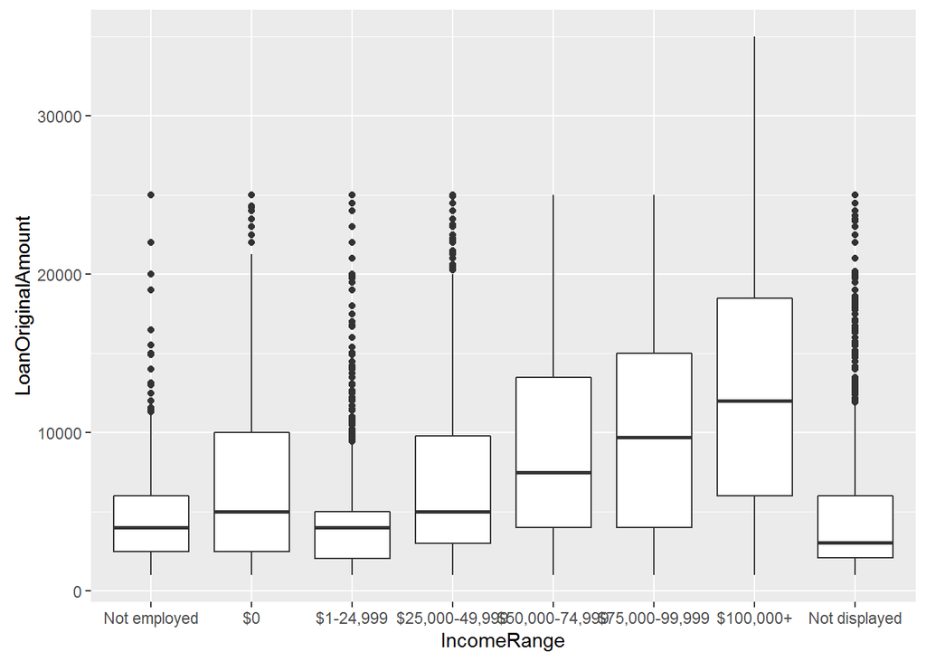

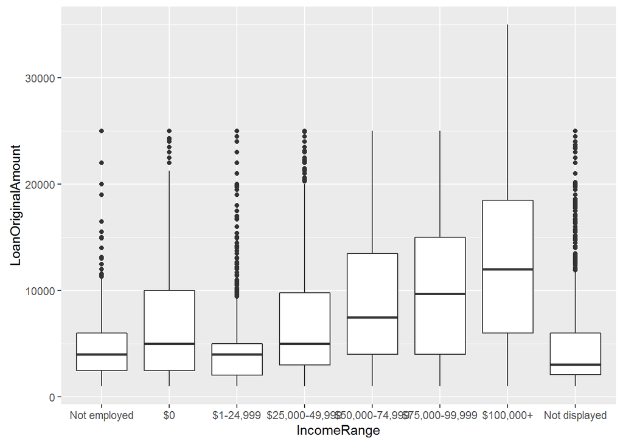

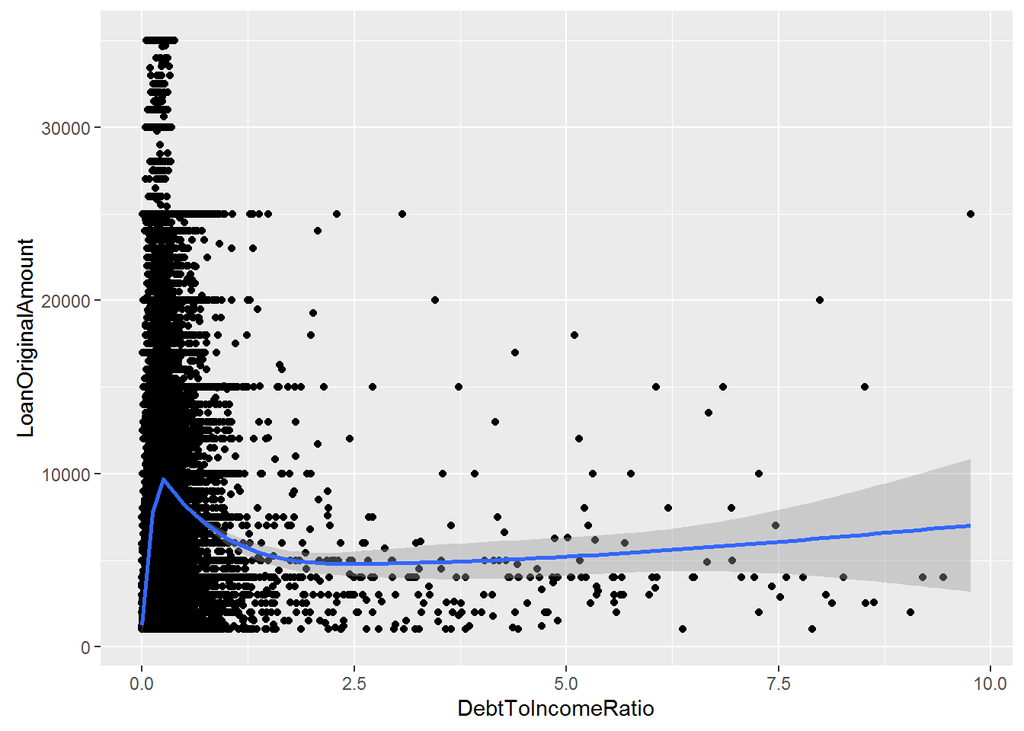

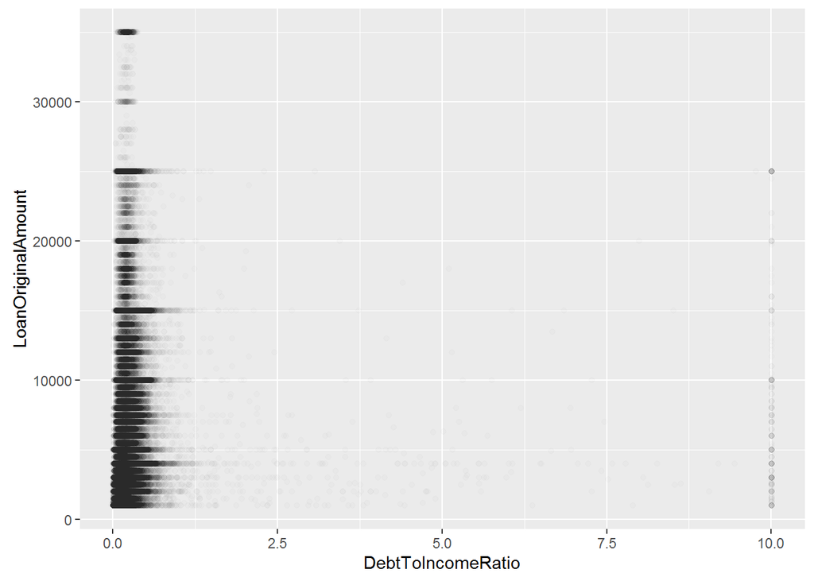